# Predicting Heart Disease using R

```r
 tibble::glimpse(explanation_cor) %>%
   kable("html", escape = FALSE, align = "c", caption = "Instrumental Songs to Exclude from Analysis") %>%
  kable_styling(bootstrap_options = c("striped", "condensed", "bordered"), full_width = FALSE)
```

```
## Observations: 25
## Variables: 13
## $ model_type       <chr> "classification", "classification", "classifi...
## $ case             <chr> "41", "41", "41", "41", "41", "46", "46", "46...
## $ label            <chr> "X2", "X2", "X2", "X2", "X2", "X1", "X1", "X1...
## $ label_prob       <dbl> 0.8560447, 0.8560447, 0.8560447, 0.8560447, 0...
## $ model_r2         <dbl> 0.1771820, 0.1771820, 0.1771820, 0.1771820, 0...
## $ model_intercept  <dbl> 0.6301624, 0.6301624, 0.6301624, 0.6301624, 0...
## $ model_prediction <dbl> 0.6233523, 0.6233523, 0.6233523, 0.6233523, 0...
## $ feature          <chr> "NUMoldpeak_eq_st_depression", "NUMnum_major_...
## $ feature_value    <dbl> 1.4, 0.0, 165.0, 154.0, 62.0, 0.2, 0.0, 175.0...
## $ feature_weight   <dbl> 0.0394578046, -0.2896498512, -0.0531320665, 0...
## $ feature_desc     <chr> "1.0 < NUMoldpeak_eq_st_depression <= 1.8", "...
## $ data             <list> [[1.4, 0, 165, 154, 62, 0, 1, 0, 1, 0, 0, 0,...
## $ prediction       <list> [[0.1439553, 0.8560447], [0.1439553, 0.85604...
```

| model_type | case | label | label_prob | model_r2 | model_intercept | model_prediction | feature | feature_value | feature_weight | feature_desc | data | prediction |
| --- | --- | --- | --- | --- | --- | --- | --- | --- | --- | --- | --- | --- |
| classification | 41 | X2 | 0.8560447 | 0.1771820 | 0.6301624 | 0.6233523 | NUMoldpeak_eq_st_depression | 1.4 | 0.0394578 | 1.0 < NUMoldpeak_eq_st_depression <= 1.8 | list(NUMoldpeak_eq_st_depression = 1.4, NUMnum_major_vessels = 0, NUMMaxHeartRateForAge = 165, NUMmax_heart_rate_achieved = 154, NUMage = 62, CATthal.fixed_defect = 0, CATthal.normal = 1, CATthal.reve… | list(X1 = 0.143955312845905, X2 = 0.856044687154095) |
| classification | 41 | X2 | 0.8560447 | 0.1771820 | 0.6301624 | 0.6233523 | NUMnum_major_vessels | 0.0 | -0.2896499 | NUMnum_major_vessels <= 1 | list(NUMoldpeak_eq_st_depression = 1.4, NUMnum_major_vessels = 0, NUMMaxHeartRateForAge = 165, NUMmax_heart_rate_achieved = 154, NUMage = 62, CATthal.fixed_defect = 0, CATthal.normal = 1, CATthal.reve… | list(X1 = 0.143955312845905, X2 = 0.856044687154095) |
| classification | 41 | X2 | 0.8560447 | 0.1771820 | 0.6301624 | 0.6233523 | NUMMaxHeartRateForAge | 165.0 | -0.0531321 | NUMMaxHeartRateForAge <= 165 | list(NUMoldpeak_eq_st_depression = 1.4, NUMnum_major_vessels = 0, NUMMaxHeartRateForAge = 165, NUMmax_heart_rate_achieved = 154, NUMage = 62, CATthal.fixed_defect = 0, CATthal.normal = 1, CATthal.reve… | list(X1 = 0.143955312845905, X2 = 0.856044687154095) |
| classification | 41 | X2 | 0.8560447 | 0.1771820 | 0.6301624 | 0.6233523 | NUMmax_heart_rate_achieved | 154.0 | 0.1170546 | 151 < NUMmax_heart_rate_achieved <= 168 | list(NUMoldpeak_eq_st_depression = 1.4, NUMnum_major_vessels = 0, NUMMaxHeartRateForAge = 165, NUMmax_heart_rate_achieved = 154, NUMage = 62, CATthal.fixed_defect = 0, CATthal.normal = 1, CATthal.reve… | list(X1 = 0.143955312845905, X2 = 0.856044687154095) |
| classification | 41 | X2 | 0.8560447 | 0.1771820 | 0.6301624 | 0.6233523 | NUMage | 62.0 | 0.1794594 | 55.0 < NUMage <= 62.8 | list(NUMoldpeak_eq_st_depression = 1.4, NUMnum_major_vessels = 0, NUMMaxHeartRateForAge = 165, NUMmax_heart_rate_achieved = 154, NUMage = 62, CATthal.fixed_defect = 0, CATthal.normal = 1, CATthal.reve… | list(X1 = 0.143955312845905, X2 = 0.856044687154095) |
| classification | 46 | X1 | 0.9980717 | 0.1885473 | 0.1945474 | 0.7803563 | NUMoldpeak_eq_st_depression | 0.2 | 0.1526357 | NUMoldpeak_eq_st_depression <= 1.0 | list(NUMoldpeak_eq_st_depression = 0.2, NUMnum_major_vessels = 0, NUMMaxHeartRateForAge = 175, NUMmax_heart_rate_achieved = 139, NUMage = 48, CATthal.fixed_defect = 0, CATthal.normal = 1, CATthal.reve… | list(X1 = 0.998071747450973, X2 = 0.00192825254902651) |
| classification | 46 | X1 | 0.9980717 | 0.1885473 | 0.1945474 | 0.7803563 | NUMnum_major_vessels | 0.0 | 0.2926397 | NUMnum_major_vessels <= 1 | list(NUMoldpeak_eq_st_depression = 0.2, NUMnum_major_vessels = 0, NUMMaxHeartRateForAge = 175, NUMmax_heart_rate_achieved = 139, NUMage = 48, CATthal.fixed_defect = 0, CATthal.normal = 1, CATthal.reve… | list(X1 = 0.998071747450973, X2 = 0.00192825254902651) |
| classification | 46 | X1 | 0.9980717 | 0.1885473 | 0.1945474 | 0.7803563 | NUMMaxHeartRateForAge | 175.0 | -0.0043484 | 170 < NUMMaxHeartRateForAge <= 175 | list(NUMoldpeak_eq_st_depression = 0.2, NUMnum_major_vessels = 0, NUMMaxHeartRateForAge = 175, NUMmax_heart_rate_achieved = 139, NUMage = 48, CATthal.fixed_defect = 0, CATthal.normal = 1, CATthal.reve… | list(X1 = 0.998071747450973, X2 = 0.00192825254902651) |
| classification | 46 | X1 | 0.9980717 | 0.1885473 | 0.1945474 | 0.7803563 | NUMmax_heart_rate_achieved | 139.0 | 0.0037924 | 130 < NUMmax_heart_rate_achieved <= 151 | list(NUMoldpeak_eq_st_depression = 0.2, NUMnum_major_vessels = 0, NUMMaxHeartRateForAge = 175, NUMmax_heart_rate_achieved = 139, NUMage = 48, CATthal.fixed_defect = 0, CATthal.normal = 1, CATthal.reve… | list(X1 = 0.998071747450973, X2 = 0.00192825254902651) |
| classification | 46 | X1 | 0.9980717 | 0.1885473 | 0.1945474 | 0.7803563 | NUMage | 48.0 | 0.1410896 | 47.2 < NUMage <= 55.0 | list(NUMoldpeak_eq_st_depression = 0.2, NUMnum_major_vessels = 0, NUMMaxHeartRateForAge = 175, NUMmax_heart_rate_achieved = 139, NUMage = 48, CATthal.fixed_defect = 0, CATthal.normal = 1, CATthal.reve… | list(X1 = 0.998071747450973, X2 = 0.00192825254902651) |
| classification | 38 | X2 | 0.7464647 | 0.2166473 | 0.7939411 | 0.3150982 | NUMoldpeak_eq_st_depression | 0.0 | -0.1668398 | NUMoldpeak_eq_st_depression <= 1.0 | list(NUMoldpeak_eq_st_depression = 0, NUMnum_major_vessels = 1, NUMMaxHeartRateForAge = 173, NUMmax_heart_rate_achieved = 154, NUMage = 51, CATthal.fixed_defect = 0, CATthal.normal = 0, CATthal.revers… | list(X1 = 0.253535322638538, X2 = 0.746464677361462) |
| classification | 38 | X2 | 0.7464647 | 0.2166473 | 0.7939411 | 0.3150982 | NUMnum_major_vessels | 1.0 | -0.2908248 | NUMnum_major_vessels <= 1 | list(NUMoldpeak_eq_st_depression = 0, NUMnum_major_vessels = 1, NUMMaxHeartRateForAge = 173, NUMmax_heart_rate_achieved = 154, NUMage = 51, CATthal.fixed_defect = 0, CATthal.normal = 0, CATthal.revers… | list(X1 = 0.253535322638538, X2 = 0.746464677361462) |
| classification | 38 | X2 | 0.7464647 | 0.2166473 | 0.7939411 | 0.3150982 | NUMMaxHeartRateForAge | 173.0 | -0.0136839 | 170 < NUMMaxHeartRateForAge <= 175 | list(NUMoldpeak_eq_st_depression = 0, NUMnum_major_vessels = 1, NUMMaxHeartRateForAge = 173, NUMmax_heart_rate_achieved = 154, NUMage = 51, CATthal.fixed_defect = 0, CATthal.normal = 0, CATthal.revers… | list(X1 = 0.253535322638538, X2 = 0.746464677361462) |
| classification | 38 | X2 | 0.7464647 | 0.2166473 | 0.7939411 | 0.3150982 | NUMmax_heart_rate_achieved | 154.0 | 0.1126702 | 151 < NUMmax_heart_rate_achieved <= 168 | list(NUMoldpeak_eq_st_depression = 0, NUMnum_major_vessels = 1, NUMMaxHeartRateForAge = 173, NUMmax_heart_rate_achieved = 154, NUMage = 51, CATthal.fixed_defect = 0, CATthal.normal = 0, CATthal.revers… | list(X1 = 0.253535322638538, X2 = 0.746464677361462) |
| classification | 38 | X2 | 0.7464647 | 0.2166473 | 0.7939411 | 0.3150982 | NUMage | 51.0 | -0.1201646 | 47.2 < NUMage <= 55.0 | list(NUMoldpeak_eq_st_depression = 0, NUMnum_major_vessels = 1, NUMMaxHeartRateForAge = 173, NUMmax_heart_rate_achieved = 154, NUMage = 51, CATthal.fixed_defect = 0, CATthal.normal = 0, CATthal.revers… | list(X1 = 0.253535322638538, X2 = 0.746464677361462) |
| classification | 47 | X1 | 0.9789453 | 0.2077067 | 0.1658191 | 0.8403552 | NUMoldpeak_eq_st_depression | 0.6 | 0.1541778 | NUMoldpeak_eq_st_depression <= 1.0 | list(NUMoldpeak_eq_st_depression = 0.6, NUMnum_major_vessels = 0, NUMMaxHeartRateForAge = 174, NUMmax_heart_rate_achieved = 171, NUMage = 49, CATthal.fixed_defect = 0, CATthal.normal = 1, CATthal.reve… | list(X1 = 0.978945302623757, X2 = 0.021054697376243) |
| classification | 47 | X1 | 0.9789453 | 0.2077067 | 0.1658191 | 0.8403552 | NUMnum_major_vessels | 0.0 | 0.3022734 | NUMnum_major_vessels <= 1 | list(NUMoldpeak_eq_st_depression = 0.6, NUMnum_major_vessels = 0, NUMMaxHeartRateForAge = 174, NUMmax_heart_rate_achieved = 171, NUMage = 49, CATthal.fixed_defect = 0, CATthal.normal = 1, CATthal.reve… | list(X1 = 0.978945302623757, X2 = 0.021054697376243) |
| classification | 47 | X1 | 0.9789453 | 0.2077067 | 0.1658191 | 0.8403552 | NUMMaxHeartRateForAge | 174.0 | -0.0006393 | 170 < NUMMaxHeartRateForAge <= 175 | list(NUMoldpeak_eq_st_depression = 0.6, NUMnum_major_vessels = 0, NUMMaxHeartRateForAge = 174, NUMmax_heart_rate_achieved = 171, NUMage = 49, CATthal.fixed_defect = 0, CATthal.normal = 1, CATthal.reve… | list(X1 = 0.978945302623757, X2 = 0.021054697376243) |
| classification | 47 | X1 | 0.9789453 | 0.2077067 | 0.1658191 | 0.8403552 | NUMmax_heart_rate_achieved | 171.0 | 0.0822492 | 168 < NUMmax_heart_rate_achieved | list(NUMoldpeak_eq_st_depression = 0.6, NUMnum_major_vessels = 0, NUMMaxHeartRateForAge = 174, NUMmax_heart_rate_achieved = 171, NUMage = 49, CATthal.fixed_defect = 0, CATthal.normal = 1, CATthal.reve… | list(X1 = 0.978945302623757, X2 = 0.021054697376243) |
| classification | 47 | X1 | 0.9789453 | 0.2077067 | 0.1658191 | 0.8403552 | NUMage | 49.0 | 0.1364751 | 47.2 < NUMage <= 55.0 | list(NUMoldpeak_eq_st_depression = 0.6, NUMnum_major_vessels = 0, NUMMaxHeartRateForAge = 174, NUMmax_heart_rate_achieved = 171, NUMage = 49, CATthal.fixed_defect = 0, CATthal.normal = 1, CATthal.reve… | list(X1 = 0.978945302623757, X2 = 0.021054697376243) |
| classification | 6 | X1 | 0.9745651 | 0.1709532 | 0.2356971 | 0.6914374 | NUMoldpeak_eq_st_depression | 0.0 | 0.1506642 | NUMoldpeak_eq_st_depression <= 1.0 | list(NUMoldpeak_eq_st_depression = 0, NUMnum_major_vessels = 0, NUMMaxHeartRateForAge = 187, NUMmax_heart_rate_achieved = 202, NUMage = 29, CATthal.fixed_defect = 0, CATthal.normal = 1, CATthal.revers… | list(X1 = 0.97456506312135, X2 = 0.0254349368786497) |
| classification | 6 | X1 | 0.9745651 | 0.1709532 | 0.2356971 | 0.6914374 | NUMnum_major_vessels | 0.0 | 0.2886934 | NUMnum_major_vessels <= 1 | list(NUMoldpeak_eq_st_depression = 0, NUMnum_major_vessels = 0, NUMMaxHeartRateForAge = 187, NUMmax_heart_rate_achieved = 202, NUMage = 29, CATthal.fixed_defect = 0, CATthal.normal = 1, CATthal.revers… | list(X1 = 0.97456506312135, X2 = 0.0254349368786497) |
| classification | 6 | X1 | 0.9745651 | 0.1709532 | 0.2356971 | 0.6914374 | NUMMaxHeartRateForAge | 187.0 | -0.0593804 | 175 < NUMMaxHeartRateForAge | list(NUMoldpeak_eq_st_depression = 0, NUMnum_major_vessels = 0, NUMMaxHeartRateForAge = 187, NUMmax_heart_rate_achieved = 202, NUMage = 29, CATthal.fixed_defect = 0, CATthal.normal = 1, CATthal.revers… | list(X1 = 0.97456506312135, X2 = 0.0254349368786497) |
| classification | 6 | X1 | 0.9745651 | 0.1709532 | 0.2356971 | 0.6914374 | NUMmax_heart_rate_achieved | 202.0 | 0.0906439 | 168 < NUMmax_heart_rate_achieved | list(NUMoldpeak_eq_st_depression = 0, NUMnum_major_vessels = 0, NUMMaxHeartRateForAge = 187, NUMmax_heart_rate_achieved = 202, NUMage = 29, CATthal.fixed_defect = 0, CATthal.normal = 1, CATthal.revers… | list(X1 = 0.97456506312135, X2 = 0.0254349368786497) |
| classification | 6 | X1 | 0.9745651 | 0.1709532 | 0.2356971 | 0.6914374 | NUMage | 29.0 | -0.0148807 | NUMage <= 47.2 | list(NUMoldpeak_eq_st_depression = 0, NUMnum_major_vessels = 0, NUMMaxHeartRateForAge = 187, NUMmax_heart_rate_achieved = 202, NUMage = 29, CATthal.fixed_defect = 0, CATthal.normal = 1, CATthal.revers… | list(X1 = 0.97456506312135, X2 = 0.0254349368786497) |

```r
 tibble::glimpse(explanation_wrong) %>%
  kable("html", escape = FALSE, align = "c", caption = "Instrumental Songs to Exclude from Analysis") %>%
  kable_styling(bootstrap_options = c("striped", "condensed", "bordered"), full_width = FALSE)
```

```
## Observations: 25
## Variables: 13
## $ model_type       <chr> "classification", "classification", "classifi...
## $ case             <chr> "14", "14", "14", "14", "14", "20", "20", "20...
## $ label            <chr> "X2", "X2", "X2", "X2", "X2", "X1", "X1", "X1...
## $ label_prob       <dbl> 0.8218592, 0.8218592, 0.8218592, 0.8218592, 0...
## $ model_r2         <dbl> 0.2362053, 0.2362053, 0.2362053, 0.2362053, 0...
## $ model_intercept  <dbl> 0.8370332, 0.8370332, 0.8370332, 0.8370332, 0...
## $ model_prediction <dbl> 0.3109340, 0.3109340, 0.3109340, 0.3109340, 0...
## $ feature          <chr> "NUMoldpeak_eq_st_depression", "NUMnum_major_...
## $ feature_value    <dbl> 0.0, 1.0, 172.0, 161.0, 52.0, 0.0, 0.0, 173.0...
## $ feature_weight   <dbl> -0.157772438, -0.330185844, 0.005621229, 0.10...
## $ feature_desc     <chr> "NUMoldpeak_eq_st_depression <= 1.0", "NUMnum...
## $ data             <list> [[0, 1, 172, 161, 52, 0, 0, 1, 1, 0, 0, 0, 0...
## $ prediction       <list> [[0.1781408, 0.8218592], [0.1781408, 0.82185...
```

| model_type | case | label | label_prob | model_r2 | model_intercept | model_prediction | feature | feature_value | feature_weight | feature_desc | data | prediction |
| --- | --- | --- | --- | --- | --- | --- | --- | --- | --- | --- | --- | --- |
| classification | 14 | X2 | 0.8218592 | 0.2362053 | 0.8370332 | 0.3109340 | NUMoldpeak_eq_st_depression | 0.0 | -0.1577724 | NUMoldpeak_eq_st_depression <= 1.0 | list(NUMoldpeak_eq_st_depression = 0, NUMnum_major_vessels = 1, NUMMaxHeartRateForAge = 172, NUMmax_heart_rate_achieved = 161, NUMage = 52, CATthal.fixed_defect = 0, CATthal.normal = 0, CATthal.revers… | list(X1 = 0.178140847178808, X2 = 0.821859152821192) |
| classification | 14 | X2 | 0.8218592 | 0.2362053 | 0.8370332 | 0.3109340 | NUMnum_major_vessels | 1.0 | -0.3301858 | NUMnum_major_vessels <= 1 | list(NUMoldpeak_eq_st_depression = 0, NUMnum_major_vessels = 1, NUMMaxHeartRateForAge = 172, NUMmax_heart_rate_achieved = 161, NUMage = 52, CATthal.fixed_defect = 0, CATthal.normal = 0, CATthal.revers… | list(X1 = 0.178140847178808, X2 = 0.821859152821192) |
| classification | 14 | X2 | 0.8218592 | 0.2362053 | 0.8370332 | 0.3109340 | NUMMaxHeartRateForAge | 172.0 | 0.0056212 | 170 < NUMMaxHeartRateForAge <= 175 | list(NUMoldpeak_eq_st_depression = 0, NUMnum_major_vessels = 1, NUMMaxHeartRateForAge = 172, NUMmax_heart_rate_achieved = 161, NUMage = 52, CATthal.fixed_defect = 0, CATthal.normal = 0, CATthal.revers… | list(X1 = 0.178140847178808, X2 = 0.821859152821192) |
| classification | 14 | X2 | 0.8218592 | 0.2362053 | 0.8370332 | 0.3109340 | NUMmax_heart_rate_achieved | 161.0 | 0.1036086 | 151 < NUMmax_heart_rate_achieved <= 168 | list(NUMoldpeak_eq_st_depression = 0, NUMnum_major_vessels = 1, NUMMaxHeartRateForAge = 172, NUMmax_heart_rate_achieved = 161, NUMage = 52, CATthal.fixed_defect = 0, CATthal.normal = 0, CATthal.revers… | list(X1 = 0.178140847178808, X2 = 0.821859152821192) |
| classification | 14 | X2 | 0.8218592 | 0.2362053 | 0.8370332 | 0.3109340 | NUMage | 52.0 | -0.1473708 | 47.2 < NUMage <= 55.0 | list(NUMoldpeak_eq_st_depression = 0, NUMnum_major_vessels = 1, NUMMaxHeartRateForAge = 172, NUMmax_heart_rate_achieved = 161, NUMage = 52, CATthal.fixed_defect = 0, CATthal.normal = 0, CATthal.revers… | list(X1 = 0.178140847178808, X2 = 0.821859152821192) |
| classification | 20 | X1 | 0.9555428 | 0.2002230 | 0.2187021 | 0.6897227 | NUMoldpeak_eq_st_depression | 0.0 | 0.1540545 | NUMoldpeak_eq_st_depression <= 1.0 | list(NUMoldpeak_eq_st_depression = 0, NUMnum_major_vessels = 0, NUMMaxHeartRateForAge = 173, NUMmax_heart_rate_achieved = 159, NUMage = 50, CATthal.fixed_defect = 0, CATthal.normal = 1, CATthal.revers… | list(X1 = 0.955542798669123, X2 = 0.0444572013308773) |
| classification | 20 | X1 | 0.9555428 | 0.2002230 | 0.2187021 | 0.6897227 | NUMnum_major_vessels | 0.0 | 0.2894453 | NUMnum_major_vessels <= 1 | list(NUMoldpeak_eq_st_depression = 0, NUMnum_major_vessels = 0, NUMMaxHeartRateForAge = 173, NUMmax_heart_rate_achieved = 159, NUMage = 50, CATthal.fixed_defect = 0, CATthal.normal = 1, CATthal.revers… | list(X1 = 0.955542798669123, X2 = 0.0444572013308773) |
| classification | 20 | X1 | 0.9555428 | 0.2002230 | 0.2187021 | 0.6897227 | NUMMaxHeartRateForAge | 173.0 | 0.0124698 | 170 < NUMMaxHeartRateForAge <= 175 | list(NUMoldpeak_eq_st_depression = 0, NUMnum_major_vessels = 0, NUMMaxHeartRateForAge = 173, NUMmax_heart_rate_achieved = 159, NUMage = 50, CATthal.fixed_defect = 0, CATthal.normal = 1, CATthal.revers… | list(X1 = 0.955542798669123, X2 = 0.0444572013308773) |
| classification | 20 | X1 | 0.9555428 | 0.2002230 | 0.2187021 | 0.6897227 | NUMmax_heart_rate_achieved | 159.0 | -0.1251122 | 151 < NUMmax_heart_rate_achieved <= 168 | list(NUMoldpeak_eq_st_depression = 0, NUMnum_major_vessels = 0, NUMMaxHeartRateForAge = 173, NUMmax_heart_rate_achieved = 159, NUMage = 50, CATthal.fixed_defect = 0, CATthal.normal = 1, CATthal.revers… | list(X1 = 0.955542798669123, X2 = 0.0444572013308773) |
| classification | 20 | X1 | 0.9555428 | 0.2002230 | 0.2187021 | 0.6897227 | NUMage | 50.0 | 0.1401631 | 47.2 < NUMage <= 55.0 | list(NUMoldpeak_eq_st_depression = 0, NUMnum_major_vessels = 0, NUMMaxHeartRateForAge = 173, NUMmax_heart_rate_achieved = 159, NUMage = 50, CATthal.fixed_defect = 0, CATthal.normal = 1, CATthal.revers… | list(X1 = 0.955542798669123, X2 = 0.0444572013308773) |
| classification | 30 | X2 | 0.8148274 | 0.2105882 | 0.7985260 | 0.3285493 | NUMoldpeak_eq_st_depression | 0.5 | -0.1467825 | NUMoldpeak_eq_st_depression <= 1.0 | list(NUMoldpeak_eq_st_depression = 0.5, NUMnum_major_vessels = 0, NUMMaxHeartRateForAge = 175, NUMmax_heart_rate_achieved = 166, NUMage = 48, CATthal.fixed_defect = 0, CATthal.normal = 0, CATthal.reve… | list(X1 = 0.185172564918657, X2 = 0.814827435081343) |
| classification | 30 | X2 | 0.8148274 | 0.2105882 | 0.7985260 | 0.3285493 | NUMnum_major_vessels | 0.0 | -0.3006357 | NUMnum_major_vessels <= 1 | list(NUMoldpeak_eq_st_depression = 0.5, NUMnum_major_vessels = 0, NUMMaxHeartRateForAge = 175, NUMmax_heart_rate_achieved = 166, NUMage = 48, CATthal.fixed_defect = 0, CATthal.normal = 0, CATthal.reve… | list(X1 = 0.185172564918657, X2 = 0.814827435081343) |
| classification | 30 | X2 | 0.8148274 | 0.2105882 | 0.7985260 | 0.3285493 | NUMMaxHeartRateForAge | 175.0 | 0.0080907 | 170 < NUMMaxHeartRateForAge <= 175 | list(NUMoldpeak_eq_st_depression = 0.5, NUMnum_major_vessels = 0, NUMMaxHeartRateForAge = 175, NUMmax_heart_rate_achieved = 166, NUMage = 48, CATthal.fixed_defect = 0, CATthal.normal = 0, CATthal.reve… | list(X1 = 0.185172564918657, X2 = 0.814827435081343) |
| classification | 30 | X2 | 0.8148274 | 0.2105882 | 0.7985260 | 0.3285493 | NUMmax_heart_rate_achieved | 166.0 | 0.1066198 | 151 < NUMmax_heart_rate_achieved <= 168 | list(NUMoldpeak_eq_st_depression = 0.5, NUMnum_major_vessels = 0, NUMMaxHeartRateForAge = 175, NUMmax_heart_rate_achieved = 166, NUMage = 48, CATthal.fixed_defect = 0, CATthal.normal = 0, CATthal.reve… | list(X1 = 0.185172564918657, X2 = 0.814827435081343) |
| classification | 30 | X2 | 0.8148274 | 0.2105882 | 0.7985260 | 0.3285493 | NUMage | 48.0 | -0.1372690 | 47.2 < NUMage <= 55.0 | list(NUMoldpeak_eq_st_depression = 0.5, NUMnum_major_vessels = 0, NUMMaxHeartRateForAge = 175, NUMmax_heart_rate_achieved = 166, NUMage = 48, CATthal.fixed_defect = 0, CATthal.normal = 0, CATthal.reve… | list(X1 = 0.185172564918657, X2 = 0.814827435081343) |
| classification | 39 | X2 | 0.9764906 | 0.2260575 | 0.3337853 | 0.9307589 | NUMoldpeak_eq_st_depression | 3.2 | 0.2005313 | 1.8 < NUMoldpeak_eq_st_depression | list(NUMoldpeak_eq_st_depression = 3.2, NUMnum_major_vessels = 2, NUMMaxHeartRateForAge = 168, NUMmax_heart_rate_achieved = 173, NUMage = 58, CATthal.fixed_defect = 0, CATthal.normal = 0, CATthal.reve… | list(X1 = 0.0235093810810986, X2 = 0.976490618918901) |
| classification | 39 | X2 | 0.9764906 | 0.2260575 | 0.3337853 | 0.9307589 | NUMnum_major_vessels | 2.0 | 0.2727821 | 1 < NUMnum_major_vessels | list(NUMoldpeak_eq_st_depression = 3.2, NUMnum_major_vessels = 2, NUMMaxHeartRateForAge = 168, NUMmax_heart_rate_achieved = 173, NUMage = 58, CATthal.fixed_defect = 0, CATthal.normal = 0, CATthal.reve… | list(X1 = 0.0235093810810986, X2 = 0.976490618918901) |
| classification | 39 | X2 | 0.9764906 | 0.2260575 | 0.3337853 | 0.9307589 | NUMMaxHeartRateForAge | 168.0 | 0.0156140 | 165 < NUMMaxHeartRateForAge <= 170 | list(NUMoldpeak_eq_st_depression = 3.2, NUMnum_major_vessels = 2, NUMMaxHeartRateForAge = 168, NUMmax_heart_rate_achieved = 173, NUMage = 58, CATthal.fixed_defect = 0, CATthal.normal = 0, CATthal.reve… | list(X1 = 0.0235093810810986, X2 = 0.976490618918901) |
| classification | 39 | X2 | 0.9764906 | 0.2260575 | 0.3337853 | 0.9307589 | NUMmax_heart_rate_achieved | 173.0 | -0.0948041 | 168 < NUMmax_heart_rate_achieved | list(NUMoldpeak_eq_st_depression = 3.2, NUMnum_major_vessels = 2, NUMMaxHeartRateForAge = 168, NUMmax_heart_rate_achieved = 173, NUMage = 58, CATthal.fixed_defect = 0, CATthal.normal = 0, CATthal.reve… | list(X1 = 0.0235093810810986, X2 = 0.976490618918901) |
| classification | 39 | X2 | 0.9764906 | 0.2260575 | 0.3337853 | 0.9307589 | NUMage | 58.0 | 0.2028503 | 55.0 < NUMage <= 62.8 | list(NUMoldpeak_eq_st_depression = 3.2, NUMnum_major_vessels = 2, NUMMaxHeartRateForAge = 168, NUMmax_heart_rate_achieved = 173, NUMage = 58, CATthal.fixed_defect = 0, CATthal.normal = 0, CATthal.reve… | list(X1 = 0.0235093810810986, X2 = 0.976490618918901) |
| classification | 21 | X2 | 0.8087672 | 0.2024549 | 0.6165937 | 0.7077505 | NUMoldpeak_eq_st_depression | 2.2 | 0.1921254 | 1.8 < NUMoldpeak_eq_st_depression | list(NUMoldpeak_eq_st_depression = 2.2, NUMnum_major_vessels = 1, NUMMaxHeartRateForAge = 167, NUMmax_heart_rate_achieved = 134, NUMage = 59, CATthal.fixed_defect = 1, CATthal.normal = 0, CATthal.reve… | list(X1 = 0.19123283792956, X2 = 0.80876716207044) |
| classification | 21 | X2 | 0.8087672 | 0.2024549 | 0.6165937 | 0.7077505 | NUMnum_major_vessels | 1.0 | -0.2869804 | NUMnum_major_vessels <= 1 | list(NUMoldpeak_eq_st_depression = 2.2, NUMnum_major_vessels = 1, NUMMaxHeartRateForAge = 167, NUMmax_heart_rate_achieved = 134, NUMage = 59, CATthal.fixed_defect = 1, CATthal.normal = 0, CATthal.reve… | list(X1 = 0.19123283792956, X2 = 0.80876716207044) |
| classification | 21 | X2 | 0.8087672 | 0.2024549 | 0.6165937 | 0.7077505 | NUMMaxHeartRateForAge | 167.0 | 0.0280479 | 165 < NUMMaxHeartRateForAge <= 170 | list(NUMoldpeak_eq_st_depression = 2.2, NUMnum_major_vessels = 1, NUMMaxHeartRateForAge = 167, NUMmax_heart_rate_achieved = 134, NUMage = 59, CATthal.fixed_defect = 1, CATthal.normal = 0, CATthal.reve… | list(X1 = 0.19123283792956, X2 = 0.80876716207044) |
| classification | 21 | X2 | 0.8087672 | 0.2024549 | 0.6165937 | 0.7077505 | NUMmax_heart_rate_achieved | 134.0 | -0.0260506 | 130 < NUMmax_heart_rate_achieved <= 151 | list(NUMoldpeak_eq_st_depression = 2.2, NUMnum_major_vessels = 1, NUMMaxHeartRateForAge = 167, NUMmax_heart_rate_achieved = 134, NUMage = 59, CATthal.fixed_defect = 1, CATthal.normal = 0, CATthal.reve… | list(X1 = 0.19123283792956, X2 = 0.80876716207044) |
| classification | 21 | X2 | 0.8087672 | 0.2024549 | 0.6165937 | 0.7077505 | NUMage | 59.0 | 0.1840146 | 55.0 < NUMage <= 62.8 | list(NUMoldpeak_eq_st_depression = 2.2, NUMnum_major_vessels = 1, NUMMaxHeartRateForAge = 167, NUMmax_heart_rate_achieved = 134, NUMage = 59, CATthal.fixed_defect = 1, CATthal.normal = 0, CATthal.reve… | list(X1 = 0.19123283792956, X2 = 0.80876716207044) |

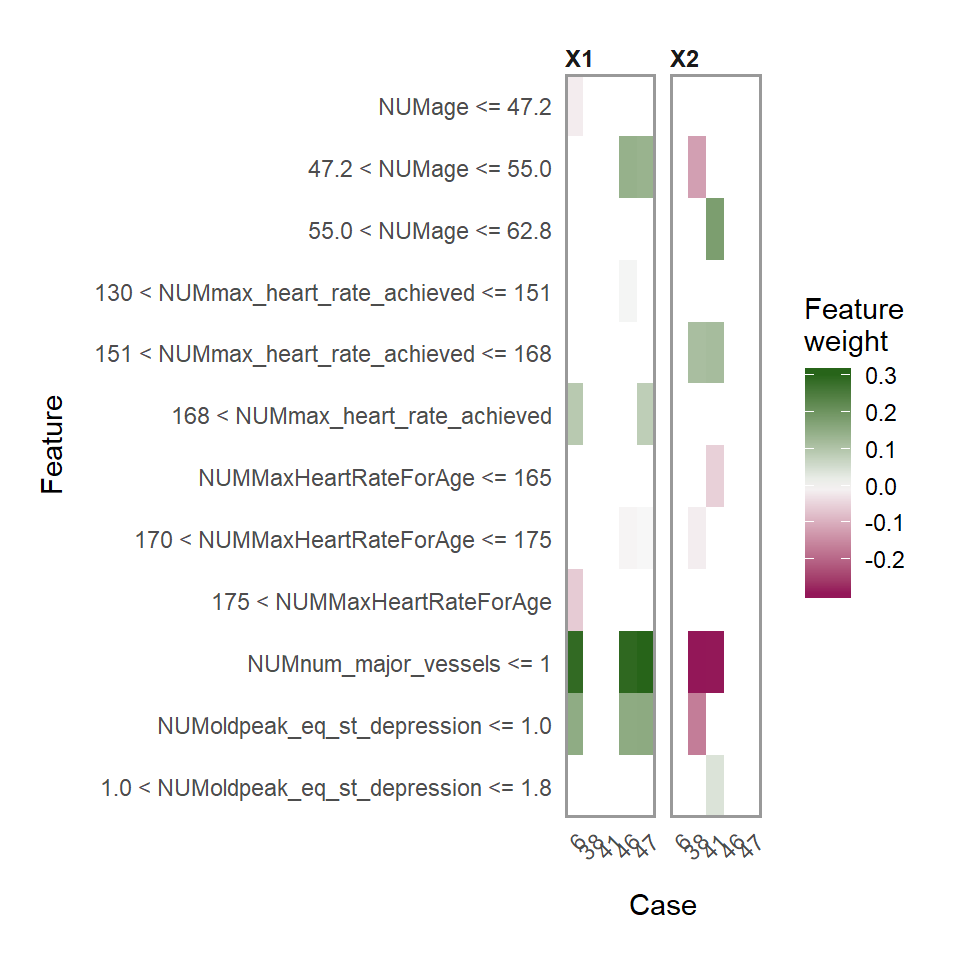

```r
 #plot_features(explainer.model.svm, ncol = 2) + ggtitle("auto")
  plot_explanations(explanation_cor)
```

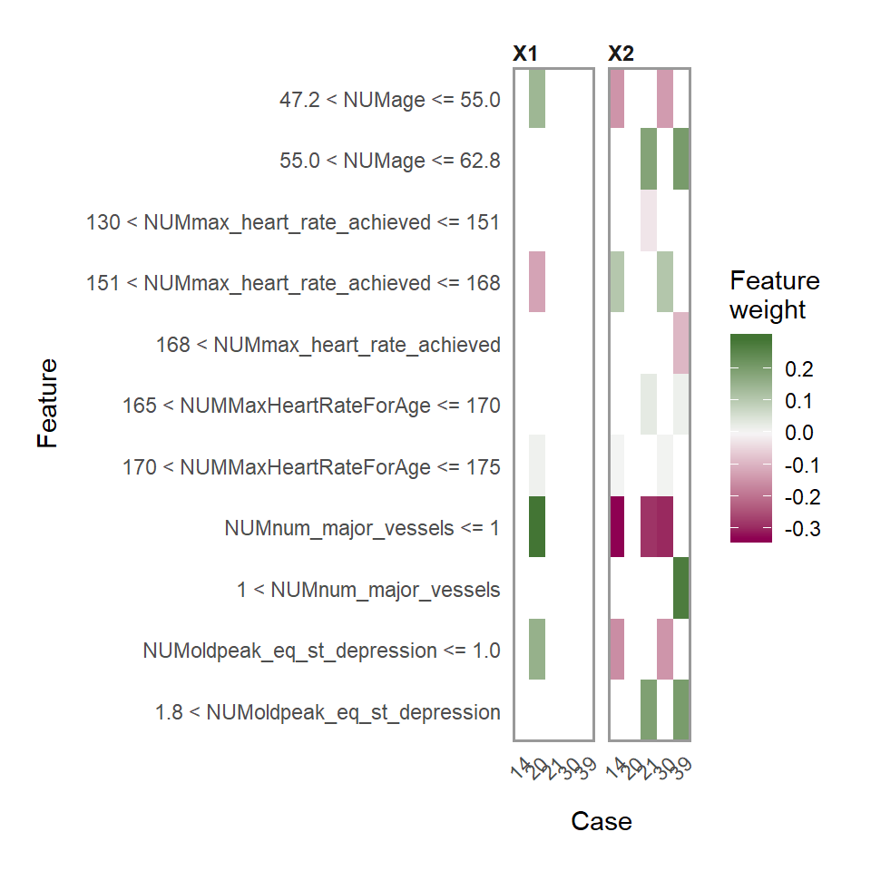

```r
  plot_explanations(explanation_wrong)
```

# Part 3: Refined iteration of modelling using XGBoost

## Lessons from first iteration of modelling and including hyper parameter tuning for xgboost model

1. Setup data for xgboost
2. Refined iteration: Feature selection
3. Training data
4. Validation data
5. Testing data
6. Hyper Parameter tuning to discover optimum parameters for model
7. Seting xgboost parameters for refined iteration
8. Build xgboost model
9. Explaining the xgboost model
   - Features of importance
   - XGB tree
   - dalex variables of importance
   - boruta variables of importance
   - lime explainer object
10. Making prediction on validation data set
    - evaluating performance
    - Error analysis - what was misclassified and why?
11. Final Submission and Prediction
    - Making prediction on final test data set (unseen data)